# Homework 1: NumPy & SciPy

Homework 1 is out, it is notebook form. You need to fill in the answers in the cells and produce graphs. Everything needed for the assignment is explained in the notebook.

**How to submit**

You need to send the `.ipynb` file with your answers plus an `.html` file, which will serve as a backup for us in case the `.ipynb` file cannot be opened on my or the TA's computer.

The homework solution should be uploaded on e-campus. You can submit it as often as you like before the deadline.

**Important**

- Please make sure that you provide an answer in each cell and place that contains the **[ your answer ]** tags.
- The places that require your code answer are marked with `"# YOUR CODE"` comments.
- Note that you may use 1 or more line of code for replacing each `"# YOUR CODE"` comment.

## NumPy

- Most common package for scientific computing with Python
- Its fundamental object is `np.array`, an multidimensional array of numbers
- Provides linear algebra, Fourier transform, random number capabilities
- Building block for other packages (e.g. SciPy, scikit-learn)
- Open source, huge dev community!

```python
import numpy as np
```

## Numpy

Main object type is `np.array`

Many ways to create it,

One way is to convert a python list

```python
python_list = [ 1,2,3 ]
np.array(python_list)
```

```
array([1, 2, 3])
```

```python
arr = np.array([1,2,3])
arr
```

```
array([1, 2, 3])
```

Many times a list comprehension is used to create a list and then converted to a array

```python
arr = np.array([ 2**i for i in [2,3,9] ])
arr
```

```
array([  4,   8, 512])
```

```python
arr = np.array([ 2**i for i in range(10) if i!= 5 ])
arr
```

```
array([  1,   2,   4,   8,  16,  64, 128, 256, 512])
```

# Question 1

Create a numpy array that contain intergers i such that 0<i<100 and $2^i$ has the last digit 6

```python
arr = np.array([ 2**i for i in range(1, 100) if (2**i)%10 == 6 ])
arr
```

```
array([16, 256, 4096, 65536, 1048576, 16777216, 268435456, 4294967296,
       68719476736, 1099511627776, 17592186044416, 281474976710656,
       4503599627370496, 72057594037927936, 1152921504606846976,
       18446744073709551616, 295147905179352825856,
       4722366482869645213696, 75557863725914323419136,
       1208925819614629174706176, 19342813113834066795298816,
       309485009821345068724781056, 4951760157141521099596496896,
       79228162514264337593543950336], dtype=object)
```

# Question 2

Create a 2D numpy array $A$ such that $A_{ij} = i\times j$

```python
def mul(i, j):
    return i*j
x, y = 10, 10  #인덱스 크기 지정
A = np.fromfunction(mul, (x, y), dtype = int) # function에 각 축의 인덱스 배열을 넘김, dtype: 함수에 전달되는 인덱스 배열의 자료형
print(A)
```

```
[[ 0  0  0  0  0  0  0  0  0  0]
 [ 0  1  2  3  4  5  6  7  8  9]
 [ 0  2  4  6  8 10 12 14 16 18]
 [ 0  3  6  9 12 15 18 21 24 27]
 [ 0  4  8 12 16 20 24 28 32 36]
 [ 0  5 10 15 20 25 30 35 40 45]
 [ 0  6 12 18 24 30 36 42 48 54]
 [ 0  7 14 21 28 35 42 49 56 63]
 [ 0  8 16 24 32 40 48 56 64 72]
 [ 0  9 18 27 36 45 54 63 72 81]]
```

## Vectorization

```python
def fn(x):
    return x*x + 4*x +5
```

```python
fn(10)
```

```
145
```

```python
fn(np.linspace(0,1,10))

# np.linspace(n, m, k) : n부터 m까지 균등 간격으로 k개를 만든 배열
# fn(np.linspace(n, m, k)) : 위의 값들을 fn에 대입
```

```
array([ 5.        ,  5.45679012,  5.9382716 ,  6.44444444,  6.97530864,
        7.5308642 ,  8.11111111,  8.71604938,  9.34567901, 10.        ])
```

# Question 3

Create an array of first 10 powers of 2

```python
np.array([2**i for i in range(10)])

# np.power(2, [0, 1, 2, 3, 4, 5, 6, 7, 8, 9]) # > dtype = int32가 붙음
```

```
array([  1,   2,   4,   8,  16,  32,  64, 128, 256, 512])
```

## Another way to create a numpy array is with initializing functions

- np.zeros
- np.ones
- np.arange

These functions along with `reshape` can be used to create initial matrix without any for loops

```python
np.zeros((10,10))
```

```
array([[0., 0., 0., 0., 0., 0., 0., 0., 0., 0.],
       [0., 0., 0., 0., 0., 0., 0., 0., 0., 0.],
       [0., 0., 0., 0., 0., 0., 0., 0., 0., 0.],
       [0., 0., 0., 0., 0., 0., 0., 0., 0., 0.],
       [0., 0., 0., 0., 0., 0., 0., 0., 0., 0.],
       [0., 0., 0., 0., 0., 0., 0., 0., 0., 0.],
       [0., 0., 0., 0., 0., 0., 0., 0., 0., 0.],
       [0., 0., 0., 0., 0., 0., 0., 0., 0., 0.],
       [0., 0., 0., 0., 0., 0., 0., 0., 0., 0.],
       [0., 0., 0., 0., 0., 0., 0., 0., 0., 0.]])
```

```python
5*np.ones((10,10))
```

```
array([[5., 5., 5., 5., 5., 5., 5., 5., 5., 5.],
       [5., 5., 5., 5., 5., 5., 5., 5., 5., 5.],
       [5., 5., 5., 5., 5., 5., 5., 5., 5., 5.],
       [5., 5., 5., 5., 5., 5., 5., 5., 5., 5.],
       [5., 5., 5., 5., 5., 5., 5., 5., 5., 5.],
       [5., 5., 5., 5., 5., 5., 5., 5., 5., 5.],
       [5., 5., 5., 5., 5., 5., 5., 5., 5., 5.],
       [5., 5., 5., 5., 5., 5., 5., 5., 5., 5.],
       [5., 5., 5., 5., 5., 5., 5., 5., 5., 5.],
       [5., 5., 5., 5., 5., 5., 5., 5., 5., 5.]])
```

```python
np.arange(2,10, 2) #끝점 미포함
```

```
array([2, 4, 6, 8])
```

You can combine these functions with arithmetic operations

```python
np.zeros((10,10)) + 5
```

```
array([[5., 5., 5., 5., 5., 5., 5., 5., 5., 5.],
       [5., 5., 5., 5., 5., 5., 5., 5., 5., 5.],
       [5., 5., 5., 5., 5., 5., 5., 5., 5., 5.],
       [5., 5., 5., 5., 5., 5., 5., 5., 5., 5.],
       [5., 5., 5., 5., 5., 5., 5., 5., 5., 5.],
       [5., 5., 5., 5., 5., 5., 5., 5., 5., 5.],
       [5., 5., 5., 5., 5., 5., 5., 5., 5., 5.],
       [5., 5., 5., 5., 5., 5., 5., 5., 5., 5.],
       [5., 5., 5., 5., 5., 5., 5., 5., 5., 5.],
       [5., 5., 5., 5., 5., 5., 5., 5., 5., 5.]])
```

```python
np.ones((10,10))*5
```

```
array([[5., 5., 5., 5., 5., 5., 5., 5., 5., 5.],
       [5., 5., 5., 5., 5., 5., 5., 5., 5., 5.],
       [5., 5., 5., 5., 5., 5., 5., 5., 5., 5.],
       [5., 5., 5., 5., 5., 5., 5., 5., 5., 5.],
       [5., 5., 5., 5., 5., 5., 5., 5., 5., 5.],
       [5., 5., 5., 5., 5., 5., 5., 5., 5., 5.],
       [5., 5., 5., 5., 5., 5., 5., 5., 5., 5.],
       [5., 5., 5., 5., 5., 5., 5., 5., 5., 5.],
       [5., 5., 5., 5., 5., 5., 5., 5., 5., 5.],
       [5., 5., 5., 5., 5., 5., 5., 5., 5., 5.]])
```

```python
np.arange(10).reshape(10,1)*np.ones((10,10))
#arange(시작(생략시 0), 끝점(미포함), step size(생략시 1) ) > 0부터 9까지 1 간격
#reshape(행 개수, 열 개수)
```

```
array([[0., 0., 0., 0., 0., 0., 0., 0., 0., 0.],
       [1., 1., 1., 1., 1., 1., 1., 1., 1., 1.],
       [2., 2., 2., 2., 2., 2., 2., 2., 2., 2.],
       [3., 3., 3., 3., 3., 3., 3., 3., 3., 3.],
       [4., 4., 4., 4., 4., 4., 4., 4., 4., 4.],
       [5., 5., 5., 5., 5., 5., 5., 5., 5., 5.],
       [6., 6., 6., 6., 6., 6., 6., 6., 6., 6.],
       [7., 7., 7., 7., 7., 7., 7., 7., 7., 7.],
       [8., 8., 8., 8., 8., 8., 8., 8., 8., 8.],
       [9., 9., 9., 9., 9., 9., 9., 9., 9., 9.]])
```

### Distinction between numpy 1D arrays and numpy 2D arrays

This tends to cause a lot of confusion for new numpy users. Follow the below examples carefully to understand the distinction.

```python
X = np.arange(10)
print(X)
print(X.shape) # 원소 개수 10, (n,): 1차원 배열 원소 n개
```

```
[0 1 2 3 4 5 6 7 8 9]
(10,)
```

```python
Y=np.arange(10).reshape(-1,1) # -1: 원래 배열 길이와 남은 차원으로 추정이 가능
print(Y)
print(Y.shape) # 원래 배열 길이 10, 열이 1개 > 행은 10개
```

```
[[0]
 [1]
 [2]
 [3]
 [4]
 [5]
 [6]
 [7]
 [8]
 [9]]
(10, 1)
```

```python
Z=np.arange(10).reshape(1,-1) # 원래 배열 길이 10, 행이 1개 > 열은 1개
print(Z)
print(Z.shape)
```

```
[[0 1 2 3 4 5 6 7 8 9]]
(1, 10)
```

```python
Z.squeeze() # 바깥쪽 axis 제거 (실질적으로 원소가 포함된 축이 아닌, 추가적으로 감싸져있는 축을 제거_shape = 1인 축)
```

```
array([0, 1, 2, 3, 4, 5, 6, 7, 8, 9])
```

```python
Mat = np.random.randn(10,10)
```

```python
Mat@X # 행렬@행렬: 행렬끼리 곱셈
```

```
array([ 33.61000942,  11.24304818, -15.60462493,  -5.51412402,
        11.99689476,  20.33461244,   6.54728237,  18.0415076 ,
       -12.93056126,  10.34544047])
```

## Array Broadcasting

Normally you only do arithmetic operations between arrays of the same dimension

```python
np.ones((5,5,5))
```

```
array([[[1., 1., 1., 1., 1.],
        [1., 1., 1., 1., 1.],
        [1., 1., 1., 1., 1.],
        [1., 1., 1., 1., 1.],
        [1., 1., 1., 1., 1.]],

       [[1., 1., 1., 1., 1.],
        [1., 1., 1., 1., 1.],
        [1., 1., 1., 1., 1.],
        [1., 1., 1., 1., 1.],
        [1., 1., 1., 1., 1.]],

       [[1., 1., 1., 1., 1.],
        [1., 1., 1., 1., 1.],
        [1., 1., 1., 1., 1.],
        [1., 1., 1., 1., 1.],
        [1., 1., 1., 1., 1.]],

       [[1., 1., 1., 1., 1.],
        [1., 1., 1., 1., 1.],
        [1., 1., 1., 1., 1.],
        [1., 1., 1., 1., 1.],
        [1., 1., 1., 1., 1.]],

       [[1., 1., 1., 1., 1.],
        [1., 1., 1., 1., 1.],
        [1., 1., 1., 1., 1.],
        [1., 1., 1., 1., 1.],
        [1., 1., 1., 1., 1.]]])
```

```python
np.ones((5,5,5)) + np.arange(5*5*5).reshape(5,5,5)
```

```
array([[[  1.,   2.,   3.,   4.,   5.],
        [  6.,   7.,   8.,   9.,  10.],
        [ 11.,  12.,  13.,  14.,  15.],
        [ 16.,  17.,  18.,  19.,  20.],
        [ 21.,  22.,  23.,  24.,  25.]],

       [[ 26.,  27.,  28.,  29.,  30.],
        [ 31.,  32.,  33.,  34.,  35.],
        [ 36.,  37.,  38.,  39.,  40.],
        [ 41.,  42.,  43.,  44.,  45.],
        [ 46.,  47.,  48.,  49.,  50.]],

       [[ 51.,  52.,  53.,  54.,  55.],
        [ 56.,  57.,  58.,  59.,  60.],
        [ 61.,  62.,  63.,  64.,  65.],
        [ 66.,  67.,  68.,  69.,  70.],
        [ 71.,  72.,  73.,  74.,  75.]],

       [[ 76.,  77.,  78.,  79.,  80.],
        [ 81.,  82.,  83.,  84.,  85.],
        [ 86.,  87.,  88.,  89.,  90.],
        [ 91.,  92.,  93.,  94.,  95.],
        [ 96.,  97.,  98.,  99., 100.]],

       [[101., 102., 103., 104., 105.],
        [106., 107., 108., 109., 110.],
        [111., 112., 113., 114., 115.],
        [116., 117., 118., 119., 120.],
        [121., 122., 123., 124., 125.]]])
```

```python
np.ones((5,5,5)) + np.arange(5).reshape(5,1,1)
```

```
array([[[1., 1., 1., 1., 1.],
        [1., 1., 1., 1., 1.],
        [1., 1., 1., 1., 1.],
        [1., 1., 1., 1., 1.],
        [1., 1., 1., 1., 1.]],

       [[2., 2., 2., 2., 2.],
        [2., 2., 2., 2., 2.],
        [2., 2., 2., 2., 2.],
        [2., 2., 2., 2., 2.],
        [2., 2., 2., 2., 2.]],

       [[3., 3., 3., 3., 3.],
        [3., 3., 3., 3., 3.],
        [3., 3., 3., 3., 3.],
        [3., 3., 3., 3., 3.],
        [3., 3., 3., 3., 3.]],

       [[4., 4., 4., 4., 4.],
        [4., 4., 4., 4., 4.],
        [4., 4., 4., 4., 4.],
        [4., 4., 4., 4., 4.],
        [4., 4., 4., 4., 4.]],

       [[5., 5., 5., 5., 5.],
        [5., 5., 5., 5., 5.],
        [5., 5., 5., 5., 5.],
        [5., 5., 5., 5., 5.],
        [5., 5., 5., 5., 5.]]])
```

```python
np.ones((1,5,5)) + np.ones((5,1,5))
```

```
array([[[2., 2., 2., 2., 2.],
        [2., 2., 2., 2., 2.],
        [2., 2., 2., 2., 2.],
        [2., 2., 2., 2., 2.],
        [2., 2., 2., 2., 2.]],

       [[2., 2., 2., 2., 2.],
        [2., 2., 2., 2., 2.],
        [2., 2., 2., 2., 2.],
        [2., 2., 2., 2., 2.],
        [2., 2., 2., 2., 2.]],

       [[2., 2., 2., 2., 2.],
        [2., 2., 2., 2., 2.],
        [2., 2., 2., 2., 2.],
        [2., 2., 2., 2., 2.],
        [2., 2., 2., 2., 2.]],

       [[2., 2., 2., 2., 2.],
        [2., 2., 2., 2., 2.],
        [2., 2., 2., 2., 2.],
        [2., 2., 2., 2., 2.],
        [2., 2., 2., 2., 2.]],

       [[2., 2., 2., 2., 2.],
        [2., 2., 2., 2., 2.],
        [2., 2., 2., 2., 2.],
        [2., 2., 2., 2., 2.],
        [2., 2., 2., 2., 2.]]])
```

# Question 4

create a 2D numpy array $A$ such that $A_{ij} = i\times j$, but without using list comprehensions. Use broadcasting instead

```python
n, m = 10, 10 #i, j의 크기 설정
i = np.arange(n).reshape(n, 1)
j = np.arange(m).reshape(1, m)
A = i*j
A
```

```
array([[ 0,  0,  0,  0,  0,  0,  0,  0,  0,  0],
       [ 0,  1,  2,  3,  4,  5,  6,  7,  8,  9],
       [ 0,  2,  4,  6,  8, 10, 12, 14, 16, 18],
       [ 0,  3,  6,  9, 12, 15, 18, 21, 24, 27],
       [ 0,  4,  8, 12, 16, 20, 24, 28, 32, 36],
       [ 0,  5, 10, 15, 20, 25, 30, 35, 40, 45],
       [ 0,  6, 12, 18, 24, 30, 36, 42, 48, 54],
       [ 0,  7, 14, 21, 28, 35, 42, 49, 56, 63],
       [ 0,  8, 16, 24, 32, 40, 48, 56, 64, 72],
       [ 0,  9, 18, 27, 36, 45, 54, 63, 72, 81]])
```

# Question 5

Use array broadcasting to create a (10,10) numpy array with values $$ A_{ij} = 2^i + j $$

```python
i = np.arange(10).reshape(10,1)
j = np.arange(10).reshape(1,10)
A = 2**i+j
A
```

```
array([[  1,   2,   3,   4,   5,   6,   7,   8,   9,  10],
       [  2,   3,   4,   5,   6,   7,   8,   9,  10,  11],
       [  4,   5,   6,   7,   8,   9,  10,  11,  12,  13],
       [  8,   9,  10,  11,  12,  13,  14,  15,  16,  17],
       [ 16,  17,  18,  19,  20,  21,  22,  23,  24,  25],
       [ 32,  33,  34,  35,  36,  37,  38,  39,  40,  41],
       [ 64,  65,  66,  67,  68,  69,  70,  71,  72,  73],
       [128, 129, 130, 131, 132, 133, 134, 135, 136, 137],
       [256, 257, 258, 259, 260, 261, 262, 263, 264, 265],
       [512, 513, 514, 515, 516, 517, 518, 519, 520, 521]])
```

## Matrix creation

There are some functions to create standard matrices

```python
np.eye(10) #단위행렬
```

```
array([[1., 0., 0., 0., 0., 0., 0., 0., 0., 0.],
       [0., 1., 0., 0., 0., 0., 0., 0., 0., 0.],
       [0., 0., 1., 0., 0., 0., 0., 0., 0., 0.],
       [0., 0., 0., 1., 0., 0., 0., 0., 0., 0.],
       [0., 0., 0., 0., 1., 0., 0., 0., 0., 0.],
       [0., 0., 0., 0., 0., 1., 0., 0., 0., 0.],
       [0., 0., 0., 0., 0., 0., 1., 0., 0., 0.],
       [0., 0., 0., 0., 0., 0., 0., 1., 0., 0.],
       [0., 0., 0., 0., 0., 0., 0., 0., 1., 0.],
       [0., 0., 0., 0., 0., 0., 0., 0., 0., 1.]])
```

```python
M = np.diag(np.arange(10)) #대각 행렬
M
```

```
array([[0, 0, 0, 0, 0, 0, 0, 0, 0, 0],
       [0, 1, 0, 0, 0, 0, 0, 0, 0, 0],
       [0, 0, 2, 0, 0, 0, 0, 0, 0, 0],
       [0, 0, 0, 3, 0, 0, 0, 0, 0, 0],
       [0, 0, 0, 0, 4, 0, 0, 0, 0, 0],
       [0, 0, 0, 0, 0, 5, 0, 0, 0, 0],
       [0, 0, 0, 0, 0, 0, 6, 0, 0, 0],
       [0, 0, 0, 0, 0, 0, 0, 7, 0, 0],
       [0, 0, 0, 0, 0, 0, 0, 0, 8, 0],
       [0, 0, 0, 0, 0, 0, 0, 0, 0, 9]])
```

```python
np.diag(M) #대각 성분 추출
```

```
array([0, 1, 2, 3, 4, 5, 6, 7, 8, 9])
```

```python
A = np.arange(30).reshape(5,3,2).transpose(1,2,0)
A.shape
#원래 배열 A[x, y, z] -transpose-> B[y, z, x] 원래 배열의 index가 transpose 순서대로 변경됨
```

```
(3, 2, 5)
```

```python
x = np.arange(3).reshape(-1,1)
y = np.arange(3).reshape(1,-1)
np.dot(x,y) #내적
```

```
array([[0, 0, 0],
       [0, 1, 2],
       [0, 2, 4]])
```

```python
x @ y
```

```
array([[0, 0, 0],
       [0, 1, 2],
       [0, 2, 4]])
```

# Question 6

Create this matrix

```
array([[5., 1., 1., 1., 1., 1., 1., 1., 1., 1., 1.],
       [1., 4., 1., 1., 1., 1., 1., 1., 1., 1., 1.],
       [1., 1., 3., 1., 1., 1., 1., 1., 1., 1., 1.],
       [1., 1., 1., 2., 1., 1., 1., 1., 1., 1., 1.],
       [1., 1., 1., 1., 1., 1., 1., 1., 1., 1., 1.],
       [1., 1., 1., 1., 1., 0., 1., 1., 1., 1., 1.],
       [1., 1., 1., 1., 1., 1., 1., 1., 1., 1., 1.],
       [1., 1., 1., 1., 1., 1., 1., 2., 1., 1., 1.],
       [1., 1., 1., 1., 1., 1., 1., 1., 3., 1., 1.],
       [1., 1., 1., 1., 1., 1., 1., 1., 1., 4., 1.],
       [1., 1., 1., 1., 1., 1., 1., 1., 1., 1., 5.]])
```

```python
a = np.ones((11, 11))
i = np.arange(11).reshape(-1,1) #대각 성분 계산을 위해 배열로 빼둠
d = np.abs(5-i).reshape(1, -1).squeeze() # 5-i의 절대값으로 대각 성분 계산
np.fill_diagonal(a, d) # 대각 성분 교체
a
```

```
array([[5., 1., 1., 1., 1., 1., 1., 1., 1., 1., 1.],
       [1., 4., 1., 1., 1., 1., 1., 1., 1., 1., 1.],
       [1., 1., 3., 1., 1., 1., 1., 1., 1., 1., 1.],
       [1., 1., 1., 2., 1., 1., 1., 1., 1., 1., 1.],
       [1., 1., 1., 1., 1., 1., 1., 1., 1., 1., 1.],
       [1., 1., 1., 1., 1., 0., 1., 1., 1., 1., 1.],
       [1., 1., 1., 1., 1., 1., 1., 1., 1., 1., 1.],
       [1., 1., 1., 1., 1., 1., 1., 2., 1., 1., 1.],
       [1., 1., 1., 1., 1., 1., 1., 1., 3., 1., 1.],
       [1., 1., 1., 1., 1., 1., 1., 1., 1., 4., 1.],
       [1., 1., 1., 1., 1., 1., 1., 1., 1., 1., 5.]])
```

## Array Indexing and Slicing

```python
arr = np.arange(10)
arr
```

```
array([0, 1, 2, 3, 4, 5, 6, 7, 8, 9])
```

```python
arr[5], arr[-2] #뒤에서 두번째
```

```
(5, 8)
```

```python
arr[3:7]
```

```
array([3, 4, 5, 6])
```

```python
arr[:-2]
```

```
array([0, 1, 2, 3, 4, 5, 6, 7])
```

```python
arr[0:6:2] # [start:stop(제외):step]
```

```
array([0, 2, 4])
```

```python
arr[5:0:-2] # step이 음수일땐 start부터 왼쪽으로 stop 전까지 원소를 가져옴
```

```
array([5, 3, 1])
```

```python
arr[::-1]
```

```
array([9, 8, 7, 6, 5, 4, 3, 2, 1, 0])
```

```python
arr[-1]
```

```
9
```

Can use all the above slicing methods for each dimension of a multidemnsional array

[figure not shown]

try it yourself

```python
a = 10*np.arange(6).reshape(-1,1)+np.arange(6)
a
```

```
array([[ 0,  1,  2,  3,  4,  5],
       [10, 11, 12, 13, 14, 15],
       [20, 21, 22, 23, 24, 25],
       [30, 31, 32, 33, 34, 35],
       [40, 41, 42, 43, 44, 45],
       [50, 51, 52, 53, 54, 55]])
```

```python
a[0,3:5]
```

```
array([3, 4])
```

# Question 7

Create the following matrix

```
array([[1., 1., 1., 1., 1., 1., 1., 1., 1., 1.],
       [1., 1., 1., 1., 1., 1., 1., 1., 1., 1.],
       [1., 1., 0., 0., 0., 0., 0., 0., 1., 1.],
       [1., 1., 0., 0., 0., 0., 0., 0., 1., 1.],
       [1., 1., 0., 0., 0., 0., 0., 0., 1., 1.],
       [1., 1., 0., 0., 0., 0., 0., 0., 1., 1.],
       [1., 1., 0., 0., 0., 0., 0., 0., 1., 1.],
       [1., 1., 0., 0., 0., 0., 0., 0., 1., 1.],
       [1., 1., 1., 1., 1., 1., 1., 1., 1., 1.],
       [1., 1., 1., 1., 1., 1., 1., 1., 1., 1.]])
```

```python
a = np.ones((10,10))
a[2:-2, 2:-2] = 0
a
```

```
array([[1., 1., 1., 1., 1., 1., 1., 1., 1., 1.],
       [1., 1., 1., 1., 1., 1., 1., 1., 1., 1.],
       [1., 1., 0., 0., 0., 0., 0., 0., 1., 1.],
       [1., 1., 0., 0., 0., 0., 0., 0., 1., 1.],
       [1., 1., 0., 0., 0., 0., 0., 0., 1., 1.],
       [1., 1., 0., 0., 0., 0., 0., 0., 1., 1.],
       [1., 1., 0., 0., 0., 0., 0., 0., 1., 1.],
       [1., 1., 0., 0., 0., 0., 0., 0., 1., 1.],
       [1., 1., 1., 1., 1., 1., 1., 1., 1., 1.],
       [1., 1., 1., 1., 1., 1., 1., 1., 1., 1.]])
```

# Question 8

Create the following matrix

```
array([[-1., -1., -1., -1., -1., -1., -1., -1., -1., -1.],
       [-1.,  0.,  1.,  2.,  3.,  4., -1., -1., -1., -1.],
       [-1.,  5.,  6.,  7.,  8.,  9., -1., -1., -1., -1.],
       [-1., 10., 11., 12., 13., 14., -1., -1., -1., -1.],
       [-1., 15., 16., 17., 18., 19., -1., -1., -1., -1.],
       [-1., 20., 21., 22., 23., 24., -1., -1., -1., -1.],
       [-1., 25., 26., 27., 28., 29., -1., -1., -1., -1.],
       [-1., 30., 31., 32., 33., 34., -1., -1., -1., -1.],
       [-1., 35., 36., 37., 38., 39., -1., -1., -1., -1.],
       [-1., -1., -1., -1., -1., -1., -1., -1., -1., -1.]])
```

```python
a = np.full((10,10), -1) # 배열 전체 -1 대입
r = np.arange(40).reshape(8,5) # 대체할 값들 해당 구간 모양대로 reshape
a[1:-1, 1:6] = r # 범위에 대체할 값들 대입
a
```

```
array([[-1, -1, -1, -1, -1, -1, -1, -1, -1, -1],
       [-1,  0,  1,  2,  3,  4, -1, -1, -1, -1],
       [-1,  5,  6,  7,  8,  9, -1, -1, -1, -1],
       [-1, 10, 11, 12, 13, 14, -1, -1, -1, -1],
       [-1, 15, 16, 17, 18, 19, -1, -1, -1, -1],
       [-1, 20, 21, 22, 23, 24, -1, -1, -1, -1],
       [-1, 25, 26, 27, 28, 29, -1, -1, -1, -1],
       [-1, 30, 31, 32, 33, 34, -1, -1, -1, -1],
       [-1, 35, 36, 37, 38, 39, -1, -1, -1, -1],
       [-1, -1, -1, -1, -1, -1, -1, -1, -1, -1]])
```

# Fancy Array Indexing

We can use numpy arrays as an index for other numpy arrays

```python
arr = np.arange(10)
arr
```

```
array([0, 1, 2, 3, 4, 5, 6, 7, 8, 9])
```

```python
idx = np.array([7,-5,2]) # 배열의 인덱스 7, 뒤에서 5번째(5), 인덱스 2 세개의 값
```

```python
arr[idx]=-1 # 위에서 참조한 세개의 값을 -1로 바꿈
arr
```

```
array([ 0,  1, -1,  3,  4, -1,  6, -1,  8,  9])
```

```python
arr<0 # 배열의 각 값이 0보다 작으면 참, 크거나 같으면 거짓
```

```
array([False, False,  True, False, False,  True, False,  True, False,
       False])
```

```python
arr[arr<0] = np.arange(3) # 배열의 원소가 음수인 값을 0, 1, 2로 대체
arr
```

```
array([0, 1, 0, 3, 4, 1, 6, 2, 8, 9])
```

For multidimensional array, array indexing works different from slicing

```python
X = np.zeros((10,10))
X[3:8,3:9]=1
X
```

```
array([[0., 0., 0., 0., 0., 0., 0., 0., 0., 0.],
       [0., 0., 0., 0., 0., 0., 0., 0., 0., 0.],
       [0., 0., 0., 0., 0., 0., 0., 0., 0., 0.],
       [0., 0., 0., 1., 1., 1., 1., 1., 1., 0.],
       [0., 0., 0., 1., 1., 1., 1., 1., 1., 0.],
       [0., 0., 0., 1., 1., 1., 1., 1., 1., 0.],
       [0., 0., 0., 1., 1., 1., 1., 1., 1., 0.],
       [0., 0., 0., 1., 1., 1., 1., 1., 1., 0.],
       [0., 0., 0., 0., 0., 0., 0., 0., 0., 0.],
       [0., 0., 0., 0., 0., 0., 0., 0., 0., 0.]])
```

```python
X = np.zeros((10,10))
X[np.arange(3,9),np.arange(3,9)]=1
X
# np.arange(3,9) = [3, 4, 5, 6, 7, 8]
# X[np.arange(3,9), np.arange(3,9)] : (3,3), (4,4), (5,5), (6,6), (7,7), (8,8)
```

```
array([[0., 0., 0., 0., 0., 0., 0., 0., 0., 0.],
       [0., 0., 0., 0., 0., 0., 0., 0., 0., 0.],
       [0., 0., 0., 0., 0., 0., 0., 0., 0., 0.],
       [0., 0., 0., 1., 0., 0., 0., 0., 0., 0.],
       [0., 0., 0., 0., 1., 0., 0., 0., 0., 0.],
       [0., 0., 0., 0., 0., 1., 0., 0., 0., 0.],
       [0., 0., 0., 0., 0., 0., 1., 0., 0., 0.],
       [0., 0., 0., 0., 0., 0., 0., 1., 0., 0.],
       [0., 0., 0., 0., 0., 0., 0., 0., 1., 0.],
       [0., 0., 0., 0., 0., 0., 0., 0., 0., 0.]])
```

[figure not shown]

# Question 9

Create the following matrix

```
array([[0., 0., 0., 0., 0., 0., 0., 0., 0., 1.],
       [0., 0., 0., 0., 0., 0., 0., 1., 0., 0.],
       [0., 0., 0., 0., 0., 1., 0., 0., 0., 0.],
       [0., 0., 0., 1., 0., 0., 0., 0., 0., 0.],
       [0., 1., 0., 0., 0., 0., 0., 0., 0., 0.],
       [0., 1., 0., 0., 0., 0., 0., 0., 0., 0.],
       [0., 0., 0., 1., 0., 0., 0., 0., 0., 0.],
       [0., 0., 0., 0., 0., 1., 0., 0., 0., 0.],
       [0., 0., 0., 0., 0., 0., 0., 1., 0., 0.],
       [0., 0., 0., 0., 0., 0., 0., 0., 0., 1.]])
```

```python
a = np.zeros((10,10))
# 1인 위치
# (0,9) 9-2*0
# (1,7) 9-2*1
# (2,5) 9-2*2
# (3,3) 9-2*3
# (4,1) 9-2*4
# (5,1) |9-2*5|
# (6,3) |9-2*6|
# (7,5) |9-2*7|
# (8,7) |9-2*8|
# (9,9) |9-2*9|
for i in range(0, 10):
    a[i,np.abs(9-2*i)] = 1
a
```

```
array([[0., 0., 0., 0., 0., 0., 0., 0., 0., 1.],
       [0., 0., 0., 0., 0., 0., 0., 1., 0., 0.],
       [0., 0., 0., 0., 0., 1., 0., 0., 0., 0.],
       [0., 0., 0., 1., 0., 0., 0., 0., 0., 0.],
       [0., 1., 0., 0., 0., 0., 0., 0., 0., 0.],
       [0., 1., 0., 0., 0., 0., 0., 0., 0., 0.],
       [0., 0., 0., 1., 0., 0., 0., 0., 0., 0.],
       [0., 0., 0., 0., 0., 1., 0., 0., 0., 0.],
       [0., 0., 0., 0., 0., 0., 0., 1., 0., 0.],
       [0., 0., 0., 0., 0., 0., 0., 0., 0., 1.]])
```

We can use `np.where`, to get indices of the `True` values in a boolean array

```python
np.where(X>0)
```

```
(array([3, 4, 5, 6, 7, 8], dtype=int64),
 array([3, 4, 5, 6, 7, 8], dtype=int64))
```

```python
#X = np.arange(10)
Y = np.zeros((10,10))
Y[np.where(X>0)]=2
Y
```

```
array([[0., 0., 0., 0., 0., 0., 0., 0., 0., 0.],
       [0., 0., 0., 0., 0., 0., 0., 0., 0., 0.],
       [0., 0., 0., 0., 0., 0., 0., 0., 0., 0.],
       [0., 0., 0., 2., 0., 0., 0., 0., 0., 0.],
       [0., 0., 0., 0., 2., 0., 0., 0., 0., 0.],
       [0., 0., 0., 0., 0., 2., 0., 0., 0., 0.],
       [0., 0., 0., 0., 0., 0., 2., 0., 0., 0.],
       [0., 0., 0., 0., 0., 0., 0., 2., 0., 0.],
       [0., 0., 0., 0., 0., 0., 0., 0., 2., 0.],
       [0., 0., 0., 0., 0., 0., 0., 0., 0., 0.]])
```

## Reduction operations

Many reduction functions are available

- np.sum, np.prod
- np.min, np.max
- np.any, np.all

Partial reductions

- np.cumsum, np.cumprod

```python
X = np.arange(100).reshape(10,10)
X
```

```
array([[ 0,  1,  2,  3,  4,  5,  6,  7,  8,  9],
       [10, 11, 12, 13, 14, 15, 16, 17, 18, 19],
       [20, 21, 22, 23, 24, 25, 26, 27, 28, 29],
       [30, 31, 32, 33, 34, 35, 36, 37, 38, 39],
       [40, 41, 42, 43, 44, 45, 46, 47, 48, 49],
       [50, 51, 52, 53, 54, 55, 56, 57, 58, 59],
       [60, 61, 62, 63, 64, 65, 66, 67, 68, 69],
       [70, 71, 72, 73, 74, 75, 76, 77, 78, 79],
       [80, 81, 82, 83, 84, 85, 86, 87, 88, 89],
       [90, 91, 92, 93, 94, 95, 96, 97, 98, 99]])
```

```python
np.sum(X),np.prod(X)
```

```
(4950, 0)
```

```python
np.prod(X,axis=1)
# axis ~= 차원 (괄호 기준으로 구분하면 편함)
# axis = 0 : 가장 바깥쪽 괄호 기준
# axis = 1 : 그 다음 괄호
# ...
# axis = n : 가장 안쪽 괄호
# ex. arr([ [ [ [1, 2], [ 3, 4] ], [ [ 5, 6], [ 7, 8] ] ],
#           [ [ [9,10], [11,12] ], [ [13,14], [15,16] ] ] ])
# axis = 0 : 1~8, 9~16 ...
# axis = 1 : 1~4, 5~8 ...
# axis = 2 : 1~2, 3~4 ...
# axis = 3 : 1, 2, 3, 4 ...
```

```
array([          0,   213837312,  1168737792, -1545401344,   309180416,
        -615346432,  -870920192,   790797568,   507332608,   693482496])
```

```python
np.min(X),np.max(X)
```

```
(0, 99)
```

```python
np.min(X,axis=0)
```

```
array([0, 1, 2, 3, 4, 5, 6, 7, 8, 9])
```

```python
Y = X<1
Y
```

```
array([[ True, False, False, False, False, False, False, False, False,
        False],
       [False, False, False, False, False, False, False, False, False,
        False],
       [False, False, False, False, False, False, False, False, False,
        False],
       [False, False, False, False, False, False, False, False, False,
        False],
       [False, False, False, False, False, False, False, False, False,
        False],
       [False, False, False, False, False, False, False, False, False,
        False],
       [False, False, False, False, False, False, False, False, False,
        False],
       [False, False, False, False, False, False, False, False, False,
        False],
       [False, False, False, False, False, False, False, False, False,
        False],
       [False, False, False, False, False, False, False, False, False,
        False]])
```

```python
np.any(Y)
```

```
True
```

```python
np.all(Y)
```

```
False
```

All the above functions can be called on the array object directly

```python
X.max(axis=0)
```

```
array([90, 91, 92, 93, 94, 95, 96, 97, 98, 99])
```

```python
(np.sqrt(X*X*X)<5000).all()
```

```
True
```

```python
np.cumsum(np.ones((10,10)),axis=1)
# cumsum: 누적합(cumulative sum) 함수
# axis = 1: 행(아래로는 증가x, 다음 행에서 초기화)은 고정, 열 방향(오른쪽으론 합해감)으로 누적 합 계산
```

```
array([[ 1.,  2.,  3.,  4.,  5.,  6.,  7.,  8.,  9., 10.],
       [ 1.,  2.,  3.,  4.,  5.,  6.,  7.,  8.,  9., 10.],
       [ 1.,  2.,  3.,  4.,  5.,  6.,  7.,  8.,  9., 10.],
       [ 1.,  2.,  3.,  4.,  5.,  6.,  7.,  8.,  9., 10.],
       [ 1.,  2.,  3.,  4.,  5.,  6.,  7.,  8.,  9., 10.],
       [ 1.,  2.,  3.,  4.,  5.,  6.,  7.,  8.,  9., 10.],
       [ 1.,  2.,  3.,  4.,  5.,  6.,  7.,  8.,  9., 10.],
       [ 1.,  2.,  3.,  4.,  5.,  6.,  7.,  8.,  9., 10.],
       [ 1.,  2.,  3.,  4.,  5.,  6.,  7.,  8.,  9., 10.],
       [ 1.,  2.,  3.,  4.,  5.,  6.,  7.,  8.,  9., 10.]])
```

Cumulative operations don't change the shape of the array

```python
np.cumsum(X,axis=0)
# 기존 X가 arange(100).reshape(10,10)
# axis = 0: 세로 방향으로 누적 합
```

```
array([[  0,   1,   2,   3,   4,   5,   6,   7,   8,   9],
       [ 10,  12,  14,  16,  18,  20,  22,  24,  26,  28],
       [ 30,  33,  36,  39,  42,  45,  48,  51,  54,  57],
       [ 60,  64,  68,  72,  76,  80,  84,  88,  92,  96],
       [100, 105, 110, 115, 120, 125, 130, 135, 140, 145],
       [150, 156, 162, 168, 174, 180, 186, 192, 198, 204],
       [210, 217, 224, 231, 238, 245, 252, 259, 266, 273],
       [280, 288, 296, 304, 312, 320, 328, 336, 344, 352],
       [360, 369, 378, 387, 396, 405, 414, 423, 432, 441],
       [450, 460, 470, 480, 490, 500, 510, 520, 530, 540]], dtype=int32)
```

# Question 10

- Given X matrix below,
- Find the column with maximum column sum
- For which rows of the matrix, the sum of the first three elements of the row is greater than the sum of the last two elements of the row. We can use `np.where`.

```python
np.random.seed(10)
X = np.random.rand(5,5)
X
```

```
array([[0.77132064, 0.02075195, 0.63364823, 0.74880388, 0.49850701],
       [0.22479665, 0.19806286, 0.76053071, 0.16911084, 0.08833981],
       [0.68535982, 0.95339335, 0.00394827, 0.51219226, 0.81262096],
       [0.61252607, 0.72175532, 0.29187607, 0.91777412, 0.71457578],
       [0.54254437, 0.14217005, 0.37334076, 0.67413362, 0.44183317]])
```

```python
a = np.sum(X, axis=0) # 각 column의 sum을 계산 후 배열에 저장
idx = np.argmax(a) # column sum이 max인 원소의 index를 return
idx # the column with maximum column sum is column 3
```

```
3
```

```python
XLeft = X[:, 0:3] # matrix of first three elements
XRight = X[:, 3:5] # matrix of last two elements
#resLeft = np.sum(XLeft, axis=1)
#resRight = np.sum(XRight, axis=1)
#print(resLeft)
#print(resRight)
idx = np.where(np.sum(XLeft, axis=1) > np.sum(XRight, axis=1)) #왼쪽 > 오른쪽인 row의 index만 추출
print(idx[0].tolist()) #np.where의 결과는 tuple, list로 변환해서 구하고자 하는 row의 index를 list로 출력
# rows that the sum of first three elements of the row
# is greater than the sum of the last two elements of the row
# are row 0, 1, 2
```

```
[0, 1, 2]
```

## SciPy

Scipy is a collection of packages that provide useful mathematical functions commonly used for scientific computing.

List of subpackages

- cluster : Clustering algorithms
- constants : Physical and mathematical constants
- fftpack : Fast Fourier Transform routines
- integrate : Integration and ordinary differential equation solvers
- interpolate : Interpolation and smoothing splines
- io : Input and Output
- linalg : Linear algebra
- ndimage : N-dimensional image processing
- odr : Orthogonal distance regression
- optimize : Optimization and root-finding routines
- signal : Signal processing
- sparse : Sparse matrices and associated routines
- spatial : Spatial data structures and algorithms
- special : Special functions
- stats : Statistical distributions and functions

## Interpolation : `scipy.interpolate`

```python
import scipy.interpolate as interp
import numpy as np
import matplotlib.pyplot as plt
```

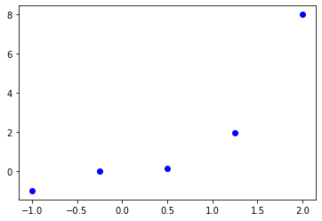

```python
x = np.linspace(-1,2,5);
y = x**3
plt.plot(x,y,'bo')
```

# Question 11

Create a cubic interpolation function

```python
f = interp.interp1d(x, y, kind = 'cubic')
```

```python
# new x points are given as:
xnew = np.linspace(-1,2,100)
```

Apply your interpolation function to find the value of new points

```python
ynew = f(xnew)
ynew
```

```
array([-1.00000000e+00, -9.11817904e-01, -8.28978490e-01, -7.51314801e-01,
       -6.78659877e-01, -6.10846760e-01, -5.47708490e-01, -4.89078109e-01,
       -4.34788658e-01, -3.84673178e-01, -3.38564710e-01, -2.96296296e-01,
       -2.57700977e-01, -2.22611793e-01, -1.90861786e-01, -1.62283997e-01,
       -1.36711467e-01, -1.13977238e-01, -9.39143501e-02, -7.63558450e-02,
       -6.11347636e-02, -4.80841473e-02, -3.70370370e-02, -2.78264741e-02,
       -2.02854996e-02, -1.42471547e-02, -9.54448062e-03, -6.01051841e-03,
       -3.47830926e-03, -1.78089434e-03, -7.51314801e-04, -2.22611793e-04,
       -2.78264741e-05,  2.77555756e-17,  2.78264741e-05,  2.22611793e-04,
        7.51314801e-04,  1.78089434e-03,  3.47830926e-03,  6.01051841e-03,
        9.54448062e-03,  1.42471547e-02,  2.02854996e-02,  2.78264741e-02,
        3.70370370e-02,  4.80841473e-02,  6.11347636e-02,  7.63558450e-02,
        9.39143501e-02,  1.13977238e-01,  1.36711467e-01,  1.62283997e-01,
        1.90861786e-01,  2.22611793e-01,  2.57700977e-01,  2.96296296e-01,
        3.38564710e-01,  3.84673178e-01,  4.34788658e-01,  4.89078109e-01,
        5.47708490e-01,  6.10846760e-01,  6.78659877e-01,  7.51314801e-01,
        8.28978490e-01,  9.11817904e-01,  1.00000000e+00,  1.09369174e+00,
        1.19306008e+00,  1.29827198e+00,  1.40949439e+00,  1.52689429e+00,
        1.65063862e+00,  1.78089434e+00,  1.91782842e+00,  2.06160781e+00,
        2.21239948e+00,  2.37037037e+00,  2.53568745e+00,  2.70851768e+00,
        2.88902802e+00,  3.07738542e+00,  3.27375685e+00,  3.47830926e+00,
        3.69120962e+00,  3.91262487e+00,  4.14272199e+00,  4.38166792e+00,
        4.62962963e+00,  4.88677408e+00,  5.15326822e+00,  5.42927902e+00,
        5.71497343e+00,  6.01051841e+00,  6.31608092e+00,  6.63182792e+00,
        6.95792637e+00,  7.29454323e+00,  7.64184545e+00,  8.00000000e+00])
```

Plot (x,y) and (xnew,ynew) using `plt.plot` and `plt.show`.

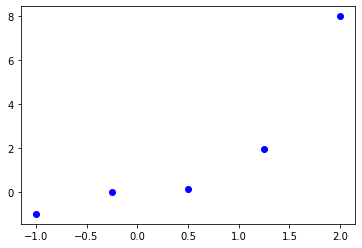

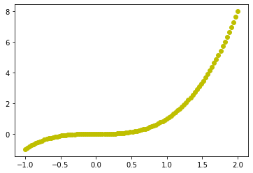

```python
plt.plot(x, y, 'bo')
plt.show()
plt.plot(xnew, ynew, 'yo')
plt.show()
```

## Numerical Integration : `scipy.integrate`

```python
import scipy.integrate as integ
```

Function is given as:

```python
def f(x):
    return x**2 + 5*x + np.sin(x)
```

# Question 12

Compute a definite integral from -1 to 1

```python
res = integ.quad(f, -1, 1)
res
```

```
(0.6666666666666667, 6.547013372677054e-14)
```